# Diabetes App

The idea for this app came from my mother, who has Type 1 diabetes. From what I've learned from her, the most challenging part of managing her condition is predicting the correct insulin dose before meals. Although there is a standard formula, it often does not work well, as everyone's situation is different. It is known that there are many factors that affect blood glucose levels ([more on tha topic](https://diabetesresearchconnection.org/42-factors-affect-blood-glucose/)).

My idea was to create a tool that would analyse historical data of individuals with Type 1 diabetes, helping them to make an informed decision about insulin delivery based on their own records, rather than relying solely on a universal formula.

The process consisted of two stages: initial data analysis and application development. Initial data analysis was conducted to gain an understanding of the data and its structure, while application development was used to create a functional program that utilized the data.

## 1. Data analysis

The data analysis part contained 6 main steps:

- Merging available data into one data frame
- Preprocessing: dropping or filling missing data, selecting relevant features, arranging into meal intervals
- Adding a recommended insulin dose feature (Y-shID), which would later become a y label for prediction
- Exploratory data analysis to identify relationships between features and identify outliers in the data
- Selecting an optimal clustering algorithm
- Choosing an optimal prediction algorithm (the candidate algorithms were tested on clusters of different sizes)

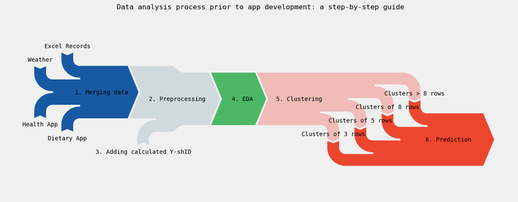

### Merging data

At first, all the relevant data were collected, including data from the iOS Health App regarding physical activity, an app tracking insulin delivery and carb intake, manual records in Excel, and historical weather data. The data were then cleaned, formatted, and combined into four CSV files, ready for merging:

1. Health app data preprocessing ([view the notebook](https://github.com/vivelafefe/diabetes-app/blob/9846d437f7db94aab4089edc6dfd0e0a2e6f735b/DiabetesApp_1_1DataMerging_HealthApp.ipynb))
2. Dietary app data preprocessing ([view the notebook](https://github.com/vivelafefe/diabetes-app/blob/a2b6b1f4ebb663a7b376bd5fb350ddf671a79988/DiabetesApp_1_1DataMerging_DiabetApp.ipynb))
3. Excel records data preprocessing ([view the notebook](https://github.com/vivelafefe/diabetes-app/blob/a2b6b1f4ebb663a7b376bd5fb350ddf671a79988/DiabetesApp_1_1DataMerging_Excel.ipynb))
4. Weather data preprocessing ([view the notebook](https://github.com/vivelafefe/diabetes-app/blob/db332e409d401408844924fbd3065a9150f116b5/DiabetesApp_1_1DataMerging_Weather.ipynb))

The preprocessed data from four different sources were merged into one data frame ([view the notebook](https://github.com/vivelafefe/diabetes-app/blob/b687a5e96e0c4209d8e4b919239fafcb57122440/DiabetesApp_1_1DataMerging_FullData.ipynb)).

### Preprocessing

The data was then organized into three intervals: breakfast-lunch, lunch-dinner, dinner-breakfast. For each interval, the following features were included:

- basal insulin delivery (bID)
- pre-meal blood glucose level (BG1)
- after-meal blood glucose level (BG2)
- dietary value (DV)
- short acting insulin delivery (shID)
- step count (SC)
- heart rate (HR)
- outside temperature (Temp)
- humidity (Humid)

### Adding calculated Y-shID

Y-shID was calculated based on pre-meal glucose level (BG1), after-meal glucose level (BG2), short acting insulin delivery (shID) and a target after-meal glucose level of 4.7 mmol/l, set by the patient ([view the notebook](https://github.com/vivelafefe/diabetes-app/blob/e409deaca4e042ac0bc35787c3cb4faeb41ad30a/DiabetesApp_1_2_3PreprocessingAndYshID.ipynb)).

### EDA

Exploratory data analysis was performed to identify relationships between features and to determine how insulin sensitivity is impacted by external factors ([view the notebook](https://github.com/vivelafefe/diabetes-app/blob/05f391403dc017103f3a2536a78111a515a3d3b1/EDA.ipynb)).

### Clustering

Initially, two main clustering algorithms were taken into account: K-Means clustering and Agglomerative clustering. K-Means was disregarded due to its limitation in accurately determining the number of clusters. By contrast, Hierarchical clustering had the great advantage of allowing the tuning of the cluster linkage distance parameter ([view the notebook](https://github.com/vivelafefe/diabetes-app/blob/a5d096294876d6f05adbfaf4bca2128ca2850781/DiabetesApp_1_5Clustering.ipynb)).

### Prediction

Initially, three regression algorithms were compared: Linear Regression, Polynomial Regression, and Elastic Net. After careful consideration, Elastic Net was eliminated first as it required some hyperparameter tuning for each instance, which would not be feasible for the user of the app alone. Although Polynomial Regression performed slightly better, the improvement was not significant enough to justify the additional processing time that would be required by the app's code ([view the notebook](https://github.com/vivelafefe/diabetes-app/blob/9096bc16f783bad13abb71ea63a5f9f6decf6d95/DiabetesApp_1_6Prediction.ipynb)).

## 2. App development

Once the algorithms were chosen and the new database with correctly recorded parameters was created, the app was ready to be built. The app follows the following logic:

- it reads data from the database stored on Google Drive
- then it normalizes and clusters selected features
- it predicts the insulin dose within a cluster where the input data belongs
- visualises the data in the cluster
- dynamically changes the visualisation and the prediction dependent on the UI widgets values

The dynamic UI was built using Holoviz Panel, and was deployed via MyBinder, so it could be accessed remotely ([view the notebook](https://github.com/vivelafefe/diabetes-app/blob/ba363a1763d8b1f93b3ef3b922e6f5a839386fa0/DiabetesApp_2_AppDevelopment.ipynb)).

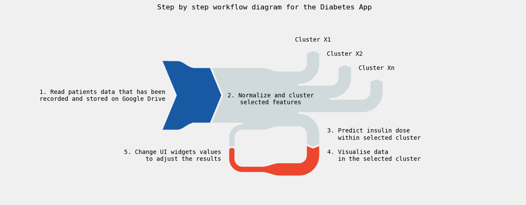

The app is now live and usable, allowing to automate the analysis that my mother used to do manually. Despite this, there are still some drawbacks to the application, such as slow speed and overfitting when the clusters selected are too large or small.

Working on this project has been an incredibly rewarding experience, as I was able to learn every aspect of data manipulation from pre-processing, to descriptive analysis and machine learning.